# Puma versus fish

It is November 17th, 2020. You are camping in the Indian Peaks and have just run out of food. But COVID is raging, Trump is still president, and avocados haven’t been on sale at King Soopers for two weeks, so you are staying put. You have a fishing rod and your specialized mountain lion suffocating gear (your bare hands). You are trying to decide whether fish (from the nearby lake) or puma have lower methylmercury levels and therefore which one you should hunt to eat.

Fortunately for you, you discover a boulder near your camping spot with some very helpful information carved onto its surface left by a scientist having an existential crises about their only mark on the world being unread journal arcticles. This information is compiled into a table below to ease the strain on your weary, hungered eyes.

# Rock info

```r
rock_etching_info <- tibble(
  species = c("lake diatoms", "lake zooplankton", "lake fish", "terrestrial vegetation", "spiders", "puma"),
  d_13C = c(-13,-14,-15,-29,-28.5,-24),
  d_15N = c(-0.6,3.2,5.5,-3.5,1.2,7.2)
)
rock_etching_info
```

| species | d_13C | d_15N |
| --- | --- | --- |
| lake diatoms | -13.0 | -0.6 |
| lake zooplankton | -14.0 | 3.2 |
| lake fish | -15.0 | 5.5 |
| terrestrial vegetation | -29.0 | -3.5 |
| spiders | -28.5 | 1.2 |
| puma | -24.0 | 7.2 |

# Mapping out potential food chain

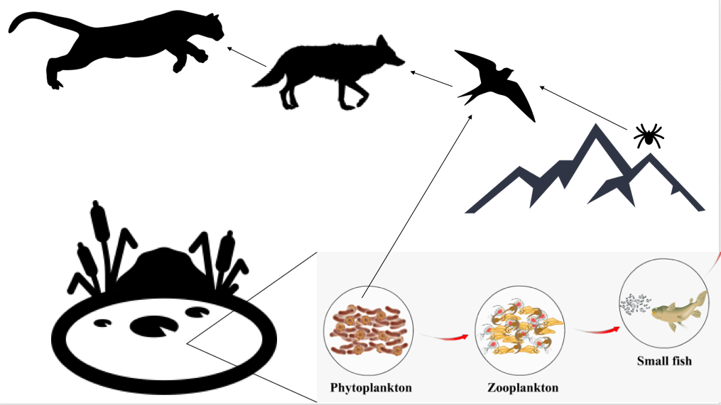

Aquatic and terrestrial trophic levels

#Q1. How much C in puma and fish came from aquatic sources? Save aquatic fractions as f_aq_puma and f_aq_fish.

```r
f_aq_puma <- ((-24) - (-28.5))/((-13)-(-28.5))
f_aq_puma
```

```
## [1] 0.2903226
```

```r
f_aq_fish <- ((-15) - (-29))/((-13)-(-29))
f_aq_fish
```

```
## [1] 0.875
```

Solution: 29% of carbon eaten by puma and 88% of carbon eaten by fish is originally sourced from an aquatic source.

#Q2. What trophic levels are fish and puma at?

$$\text{Fish Trophic Position} = 1 + \frac{\delta^{15}N_{fish} - \delta^{15}N_{aq}}{\epsilon_{trophic}}\\
\space\\
\text{Puma Trophic Position} = 1 + \frac{(\delta^{15}N_{puma} - [\delta^{15}N_{aq} \cdot f_{aq}+\delta^{15}N_{terr}\cdot(1-f_{aq}) ])}{\epsilon_{trophic}}\\
\space\\
\epsilon_{trophic} = 3$$

```r
rock_etching_info # rerun to have easy access to values
```

| species | d_13C | d_15N |
| --- | --- | --- |
| lake diatoms | -13.0 | -0.6 |
| lake zooplankton | -14.0 | 3.2 |
| lake fish | -15.0 | 5.5 |
| terrestrial vegetation | -29.0 | -3.5 |
| spiders | -28.5 | 1.2 |
| puma | -24.0 | 7.2 |

```r
fish_troph <- 1 + ((5.5 - (-0.6))/3)
fish_troph
```

```
## [1] 3.033333
```

```r
puma_troph <- 1 + ((7.2 - (-0.6*f_aq_puma + (-3.5) * (1-f_aq_puma)))/3)
puma_troph
```

```
## [1] 4.286022
```

## Q3A. How much MeHg is in the fish?

```r
MeHg <- 4.5
MeHg_fish <- MeHg * 3^fish_troph
MeHg_fish
```

```
## [1] 126.0319
```

## Q3B. How much MeHg is in the puma?

```r
MeHg_puma <- MeHg * f_aq_puma * 3^puma_troph
MeHg_puma
```

```
## [1] 144.8923
```

# Q4.